# The public and economic impact of storms

Dave Gerson

Sunday, May 17, 2015

# The public and economic impact of storms

In this paper we aim to analyze and study the impact of storms. Storms and ofther various weather related incidents lead to a tragic losses, both human and financial.

```r
wd <- "C:/Users/gerson64/Desktop/Dropbox Sync/Dropbox/Coursera/reproducibleresearch/project2/"
setwd(wd)
#Loading and preprocessing the data
dat <- read.csv("repdata-data-StormData.csv" , stringsAsFactors = FALSE)
```

### Public Damage reports

In order to assess the damage we have to take two factors into account. Since both injury and deaths need to be accounted for I defined a measure that accounts for both. Since deaths and injuries aren’t and apples to oranges comparison I decided that all deaths should be at the bare minimum equivalent to 10 injuries. So I define this as a measure using the aggregate function. To directly solve which event leads to the greatest impact I decided to use a pareto chart. Pareto charts are a type of chart developed in 6 sigma that is made to visually demonstrate the 80/20 principle.

Below it is used as a measure to analyze the health and human impacts of the top 10 events.

```r
#Most Destructive Events Pareto for people
library(qcc)
```

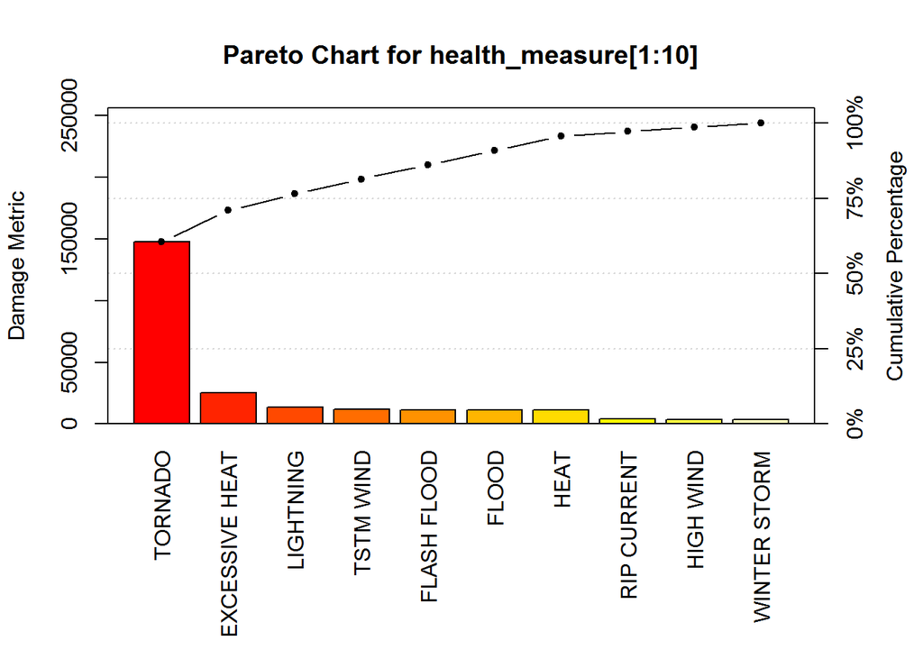

```r
pop_health <- (dat$FATALITIES * 10) + dat$INJURIES
pop_health <- aggregate( pop_health ,
    by = list( dat$EVTYPE ) ,
    FUN = sum
)
health_measure <- pop_health$x
names(health_measure) <- pop_health[,1]
health_measure <- health_measure[order(-health_measure)]

health_Pareto <- pareto.chart(health_measure[1:10], ylab = "Damage Metric")
```

```r
health_Pareto
```

```
##
## Pareto chart analysis for health_measure[1:10]
##                  Frequency Cum.Freq. Percentage Cum.Percent.
##   TORNADO           147676    147676  60.512039     60.51204
##   EXCESSIVE HEAT     25555    173231  10.471472     70.98351
##   LIGHTNING          13390    186621   5.486716     76.47023
##   TSTM WIND          11997    198618   4.915917     81.38614
##   FLASH FLOOD        11557    210175   4.735621     86.12176
##   FLOOD              11489    221664   4.707758     90.82952
##   HEAT               11470    233134   4.699972     95.52949
##   RIP CURRENT         3912    237046   1.602990     97.13248
##   HIGH WIND           3617    240663   1.482110     98.61459
##   WINTER STORM        3381    244044   1.385406    100.00000
```